# Analysis of Equating on HUM_1 Between Bank and 2023

# 1 Recommendation

A total of 12 anchors showed DIF. Please consider removing the DIF anchors of 2014_L2Q18, 2014_L2Q20, 2015_L1Q07, 2015_L1Q08, 2015_L1Q09, 2015_L1Q10, 2013_L1Q16, 2013_L1Q17, 2013_L1Q18, 2015_L1Q11, 2015_L1Q12, 2015_L1Q15.

# 2 Procedures

Table 2.1 shows the steps taken to do the Equating analysis.

Table 2.1: Steps used to detec DIF parameters

| Steps | Details |
| --- | --- |
| 1 | Calculate mean shift by subtracting Group 2’s average delta estimates from that of Group 1. |
| 2 | Adjust each delta estimate of Group 2 by adding to it the shift (Step 1). |
| 3 | Calculate delta difference by subtracting each adjusted delta of Group 2 (Step 2) from that of Group 1. |
| 4 | Adjust each delta difference (Step 3) by dividing it by adjusted error, i.e., sqrt(error.x^2 + error.y^2). |
| 5 | Perform two-side df-1 Chi-squared test on each squared adjusted delta difference (Step 4). |
| 6 | Iteratively perform Step 5 and each time remove the item of largest absolute adjusted delta difference until items all satisfy thresholds of p value, delta difference, and adjusted delta difference. |

# 3 Shift Method

Table 3.1: Shifts of statistics before and after review

| cor_bfr | shift_bfr | sdr_bfr | cor_afr | shift_afr | sdr_afr |
| --- | --- | --- | --- | --- | --- |
| -0.342 | -0.91 | 0.681 | 0.936 | -0.174 | 2.226 |

# 4 Statistics Before Review

Table 4.1 shows the parameter estimates before review. From the table, we can see that 13 parameter estimates show DIF between Bank and 2023.

Table 4.1: Parameter estimates before review

| item | delta Bank | error Bank | delta 2023 | error 2023 | delta 2023 adj | LI | UI | DIF | DIF std | chisq | p | flag |
| --- | --- | --- | --- | --- | --- | --- | --- | --- | --- | --- | --- | --- |
| 2014_L2Q18 | -1.321 | 0.03 | 0.406 | 0.045 | -0.504 | -0.967 | -0.859 | -0.817 | -15.097 | 227.922 | 0.000 | 1 |
| 2014_L2Q19 | 0.169 | 0.03 | 0.638 | 0.047 | -0.272 | -0.108 | 0.004 | 0.442 | 7.918 | 62.696 | 0.000 | 0 |
| 2014_L2Q20 | -1.976 | 0.04 | 0.665 | 0.047 | -0.245 | -1.172 | -1.049 | -1.731 | -28.039 | 786.199 | 0.000 | 1 |
| 2014_L2Q21 | -0.178 | 0.03 | -0.186 | 0.044 | -1.096 | -0.691 | -0.584 | 0.919 | 17.247 | 297.476 | 0.000 | 1 |
| 2014_L2Q22 | -0.068 | 0.03 | 0.188 | 0.045 | -0.722 | -0.449 | -0.341 | 0.654 | 12.102 | 146.451 | 0.000 | 1 |
| 2015_L1Q06 | 0.108 | 0.03 | 0.330 | 0.046 | -0.581 | -0.291 | -0.181 | 0.689 | 12.537 | 157.172 | 0.000 | 1 |
| 2015_L1Q07 | -1.892 | 0.04 | 0.722 | 0.048 | -0.188 | -1.103 | -0.978 | -1.704 | -27.264 | 743.318 | 0.000 | 1 |
| 2015_L1Q08 | -0.442 | 0.03 | 1.002 | 0.052 | 0.092 | -0.235 | -0.115 | -0.534 | -8.887 | 78.974 | 0.000 | 1 |
| 2015_L1Q09 | 0.046 | 0.03 | -0.288 | 0.045 | -1.198 | -0.630 | -0.522 | 1.244 | 23.011 | 529.498 | 0.000 | 1 |
| 2015_L1Q10 | -1.292 | 0.03 | 0.781 | 0.050 | -0.129 | -0.769 | -0.652 | -1.163 | -19.937 | 397.472 | 0.000 | 1 |
| 2013_L1Q16 | -1.026 | 0.03 | -0.137 | 0.046 | -1.047 | -1.092 | -0.982 | 0.021 | 0.391 | 0.153 | 0.695 | 0 |
| 2013_L1Q17 | -1.299 | 0.03 | 0.485 | 0.048 | -0.426 | -0.919 | -0.806 | -0.873 | -15.432 | 238.141 | 0.000 | 1 |
| 2013_L1Q18 | -0.179 | 0.03 | -0.814 | 0.049 | -1.724 | -1.009 | -0.894 | 1.545 | 26.900 | 723.590 | 0.000 | 1 |
| 2013_L1Q19 | -0.151 | 0.03 | 0.061 | 0.047 | -0.849 | -0.556 | -0.444 | 0.698 | 12.527 | 156.932 | 0.000 | 1 |
| 2015_L1Q11 | -1.026 | 0.03 | -0.133 | 0.047 | -1.043 | -1.091 | -0.979 | 0.017 | 0.314 | 0.099 | 0.754 | 0 |
| 2015_L1Q12 | -1.299 | 0.03 | -0.037 | 0.048 | -0.948 | -1.180 | -1.067 | -0.351 | -6.210 | 38.562 | 0.000 | 0 |
| 2015_L1Q13 | -0.179 | 0.03 | -0.284 | 0.048 | -1.194 | -0.743 | -0.630 | 1.015 | 17.940 | 321.860 | 0.000 | 1 |
| 2015_L1Q15 | -1.257 | 0.03 | -0.272 | 0.048 | -1.183 | -1.276 | -1.163 | -0.074 | -1.316 | 1.732 | 0.188 | 0 |

# 5 Statistics After Review

Table 5.1 shows the parameter estimates after review. Now, the statistics satisfy all the criteria.

Table 5.1: Parameter estimates after review

| item | delta Bank | error Bank | delta 2023 | error 2023 | delta 2023 adj | LI | UI | DIF | DIF std | chisq | p | flag |
| --- | --- | --- | --- | --- | --- | --- | --- | --- | --- | --- | --- | --- |
| 2014_L2Q20 | -1.976 | 0.04 | 0.665 | 0.047 | -0.245 | -1.172 | -1.049 | -1.731 | -28.039 | 786.199 | 0.000 | 1 |
| 2015_L1Q07 | -1.892 | 0.04 | 0.722 | 0.048 | -0.087 | -1.052 | -0.927 | -1.805 | -28.893 | 834.807 | 0.000 | 1 |
| 2015_L1Q10 | -1.292 | 0.03 | 0.781 | 0.050 | 0.085 | -0.662 | -0.545 | -1.377 | -23.617 | 557.786 | 0.000 | 1 |
| 2013_L1Q18 | -0.179 | 0.03 | -0.814 | 0.049 | -1.418 | -0.856 | -0.741 | 1.239 | 21.566 | 465.097 | 0.000 | 1 |
| 2013_L1Q17 | -1.299 | 0.03 | 0.485 | 0.048 | -0.208 | -0.810 | -0.697 | -1.091 | -19.282 | 371.790 | 0.000 | 1 |
| 2014_L2Q18 | -1.321 | 0.03 | 0.406 | 0.045 | -0.203 | -0.816 | -0.708 | -1.118 | -20.679 | 427.619 | 0.000 | 1 |
| 2015_L1Q09 | 0.046 | 0.03 | -0.288 | 0.045 | -0.803 | -0.433 | -0.325 | 0.849 | 15.706 | 246.670 | 0.000 | 1 |
| 2015_L1Q08 | -0.442 | 0.03 | 1.002 | 0.052 | 0.409 | -0.076 | 0.044 | -0.851 | -14.182 | 201.115 | 0.000 | 1 |
| 2015_L1Q12 | -1.299 | 0.03 | -0.037 | 0.048 | -0.544 | -0.978 | -0.865 | -0.754 | -13.329 | 177.675 | 0.000 | 1 |
| 2015_L1Q15 | -1.257 | 0.03 | -0.272 | 0.048 | -0.696 | -1.033 | -0.920 | -0.561 | -9.917 | 98.344 | 0.000 | 1 |
| 2013_L1Q16 | -1.026 | 0.03 | -0.137 | 0.046 | -0.490 | -0.813 | -0.703 | -0.536 | -9.751 | 95.080 | 0.000 | 1 |
| 2015_L1Q11 | -1.026 | 0.03 | -0.133 | 0.047 | -0.410 | -0.774 | -0.662 | -0.616 | -11.048 | 122.051 | 0.000 | 1 |
| 2014_L2Q19 | 0.169 | 0.03 | 0.638 | 0.047 | 0.464 | 0.261 | 0.372 | -0.295 | -5.285 | 27.928 | 0.000 | 0 |
| 2014_L2Q21 | -0.178 | 0.03 | -0.186 | 0.044 | -0.360 | -0.322 | -0.216 | 0.182 | 3.424 | 11.723 | 0.001 | 0 |
| 2014_L2Q22 | -0.068 | 0.03 | 0.188 | 0.045 | 0.014 | -0.081 | 0.027 | -0.082 | -1.510 | 2.280 | 0.131 | 0 |
| 2015_L1Q06 | 0.108 | 0.03 | 0.330 | 0.046 | 0.156 | 0.077 | 0.187 | -0.048 | -0.868 | 0.753 | 0.385 | 0 |
| 2013_L1Q19 | -0.151 | 0.03 | 0.061 | 0.047 | -0.113 | -0.188 | -0.076 | -0.038 | -0.676 | 0.456 | 0.499 | 0 |
| 2015_L1Q13 | -0.179 | 0.03 | -0.284 | 0.048 | -0.458 | -0.375 | -0.262 | 0.279 | 4.935 | 24.353 | 0.000 | 0 |

# 6 Scatterplot of Difficulty Estimates

Figure 6.1 shows the scatterplots of logit difficulty estimates between Bank and 2023 both before (top) and after (bottom) review. The caption at bottom right of the scatterplot on top shows all the criteria used to detect DIF item steps.

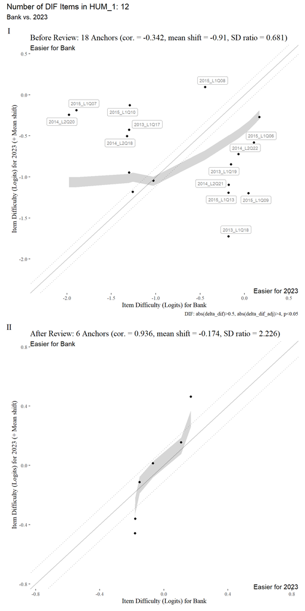

Figure 6.1: Scatterplot of logit difficulty estimates